# simon-5510-13-slides

## The S-shaped logistic curve (2/2)

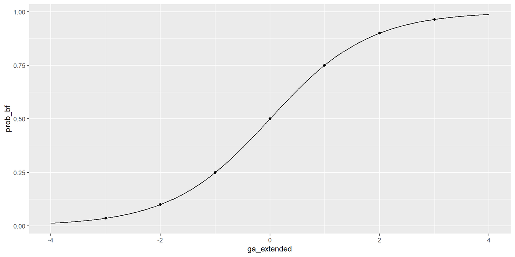

## An example of a log odds model with real data (1/2)

```
Call:  glm(formula = n ~ ga, family = binomial(), data = df, weights = w)

Coefficients:
(Intercept)           ga
   -16.7198       0.5769

Degrees of Freedom: 11 Total (i.e. Null);  10 Residual
Null Deviance:      71.98
Residual Deviance: 62.3     AIC: 66.3
```

## Predicted log odds

```
  ga   calculations log_odds
1 28 -16.72+0.58*28    -0.48
2 29 -16.72+0.58*29     0.10
3 30 -16.72+0.58*30     0.68
4 31 -16.72+0.58*31     1.26
5 32 -16.72+0.58*32     1.84
6 33 -16.72+0.58*33     2.42
```

## Predicted probabilities

```
  ga log_odds  odds prob
1 28    -0.48  0.62 0.38
2 29     0.10  1.11 0.53
3 30     0.68  1.97 0.66
4 31     1.26  3.53 0.78
5 32     1.84  6.30 0.86
6 33     2.42 11.25 0.92
```

## Plot of predicted probabilities

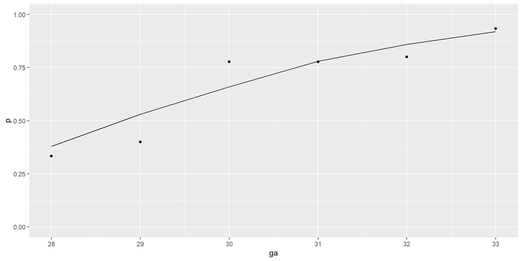

## Predicted odds and odds ratios

```
  ga log_odds  odds calculations   or
1 28    -0.48  0.62
2 29     0.10  1.11    1.11/0.62 1.79
3 30     0.68  1.97    1.97/1.11 1.77
4 31     1.26  3.53    3.53/1.97 1.79
5 32     1.84  6.30     6.3/3.53 1.78
6 33     2.42 11.25    11.25/6.3 1.79
```

## Interpretation of slope in logistic regression

- Slope in logistic regression
  - log odds ratio
    - for one unit change in x
  - exponentiate to get odds ratio

```r
exp(0.58)
```

```
[1] 1.786038
```

## Categorical variables in a logistic regression (1/2)

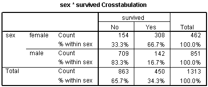

Crosstabulation of gender and mortality on the Titanic

## Categorical variables in a logistic regression (2/2)

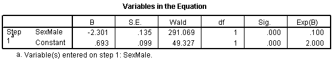

Logistic output for the Titanic data

## Alternatives to logistic regresion

- Test of two proportions
  - Only for a binary independent variable
  - No risk adjustments or interactions
- Chisquare test
  - Only for a categorical independent variable
  - Either two or more than two levels

## What if your outcomes is categorical but not binary?

- Three of more levels
  - Chi-square test
  - Multinomial logistic regression
- Ordinal outcome variable
  - Nonparametric tests
  - Ordinal logistic regression

## Categorical outcomes – summary

- Logistic regression
  - Binary outcome variable
  - Both categorical and continuous independent variables
  - Risk adjustments and interactions possible
- Alternative methods
  - Test of two proportions
  - Chi-square test
  - Multinomial logistic regression.
  - Nonparametric tests
  - Ordinal logistic regression

## Break #7

- What you have learned
  - Logistic regression
- What’s coming next
  - Poisson regression

## Poisson regression

- The problems with counts
  - Skewed
  - Non-negative
  - Unequal variances
- Analysis of rates

## Poisson regression example, responses to an ad

```
  t n
1 0 9
2 1 4
3 2 2
4 3 3
5 4 0
6 5 0
7 6 1
```

## Poisson regression example - output

```
Call:  glm(formula = n ~ t, family = poisson(), data = ad_responses)

Coefficients:
(Intercept)            t
     2.1063      -0.5505

Degrees of Freedom: 6 Total (i.e. Null);  5 Residual
Null Deviance:      22.06
Residual Deviance: 5.289    AIC: 24.21
```

```
         term estimate
1 (Intercept)     2.11
2           t    -0.55
```

## Poisson regression example: Predictions

```
  t n calculations log_count
1 0 9  2.11-0.55*0      2.11
2 1 4  2.11-0.55*1      1.56
3 2 2  2.11-0.55*2      1.01
4 3 3  2.11-0.55*3      0.46
5 4 0  2.11-0.55*4     -0.09
6 5 0  2.11-0.55*5     -0.64
7 6 1  2.11-0.55*6     -1.19
```

## Transform to count scale

```
  t n log_count count
1 0 9      2.11  8.25
2 1 4      1.56  4.76
3 2 2      1.01  2.75
4 3 3      0.46  1.58
5 4 0     -0.09  0.91
6 5 0     -0.64  0.53
7 6 1     -1.19  0.30
```

## Plot predicted counts

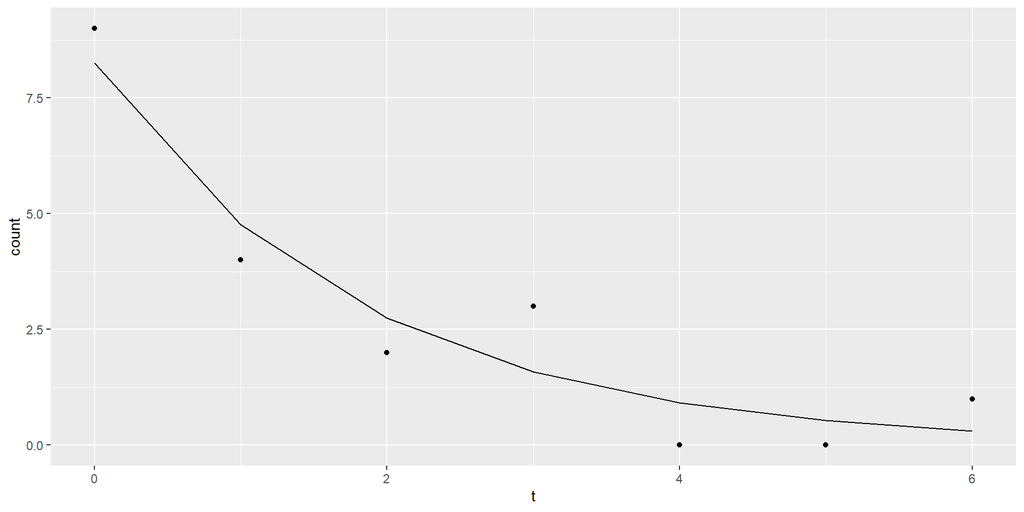

## Calculate rate ratio

```
  t n count rr_calculations   rr
1 0 9  8.25      exp(-0.55) 0.58
2 1 4  4.76       4.76/8.25 0.58
3 2 2  2.75       2.75/4.76 0.58
4 3 3  1.58       1.58/2.75 0.57
5 4 0  0.91       0.91/1.58 0.58
6 5 0  0.53       0.53/0.91 0.58
7 6 1  0.30        0.3/0.53 0.57
```

## Interpretation of slope in Poisson regression

- Slope in Poisson regression
  - log rate ratio
    - for one unit change in x
  - exponentiate to get rate ratio

```r
exp(-0.55)
```

```
[1] 0.5769498
```

## Break #8

- What you have learned
  - Poisson regression
- What’s coming next
  - Cox regression

## Time to event outcomes

- Special type of ratio scale outcome
  - Non-negative
  - Usually skewed
- Censoring
  - Partial information on some subjects
  - Not the same as missing data

## Fruit fly experiment - the data

```
Day      Day      Day      Day
 37       40       43       44
 45       47       49       54
 56       58       59       60
 61       62       68       70
 71       72       73       75
 77       79       89       94
 96
```

## Fruit fly experiment - survival probabilities

```
Day Prob Day Prob Day Prob Day Prob
 37 96%   40 92%   43 88%   44 84%
 45 80%   47 76%   49 72%   54 68%
 56 64%   58 60%   59 56%   60 52%
 61 48%   62 44%   68 40%   70 36%
 71 32%   72 28%   73 24%   75 20%
 77 16%   79 12%   89  8%   94  4%
 96  0%
```

## Here’s a graph of these probabilities over time.

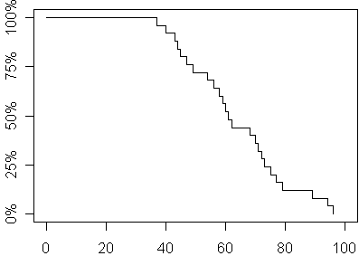

Plot of survival probabilites from first experiment

## The data, round 2

```
Day Prob  Day Prob  Day Prob  Day Prob
 37 96%    40 92%    43 88%    44 84%
 45 80%    47 76%    49 72%    54 68%
 56 64%    58 60%    59 56%    60 52%
 61 48%    62 44%    68 40%    70+ ?
 70+ ?     70+ ?     70+ ?     70+ ?
 70+ ?     70+ ?     70+ ?     70+ ?
 70+ ?
```

## The graph, round 2

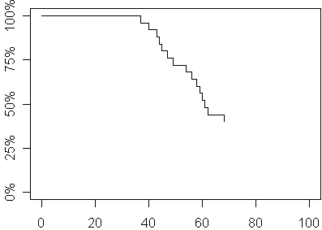

Plot of survival probabilities from second experiment

## The data, round 3

```
Day Prob  Day Prob  Day Prob  Day Prob
 37 96%    40 92%    43 88%    44 84%
 45 80%    47 76%    49 72%    54 68%
 56 64%    58 60%    59 56%    60 52%
 61 48%    62 44%    68 40%    70+ ?
 71 30%    70+ ?     70+ ?     75 20%
 70+ ?     70+ ?     89 10%    70+ ?
 96  0%
```

## The graph, round 3

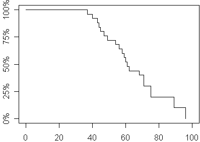

## Happy and sad corners for the Kaplan-Meier curve

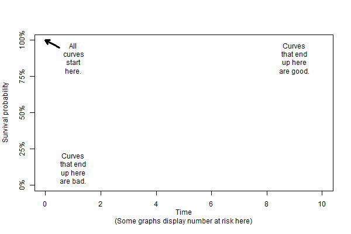

conceptual illustration of Kaplan-Meier curve regions

## Cox regression

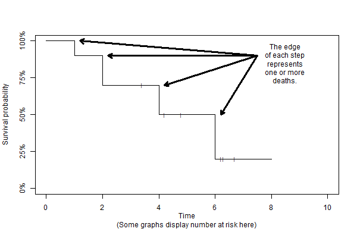

Stair steps in a Kaplan-Meier curve

## Cox regression

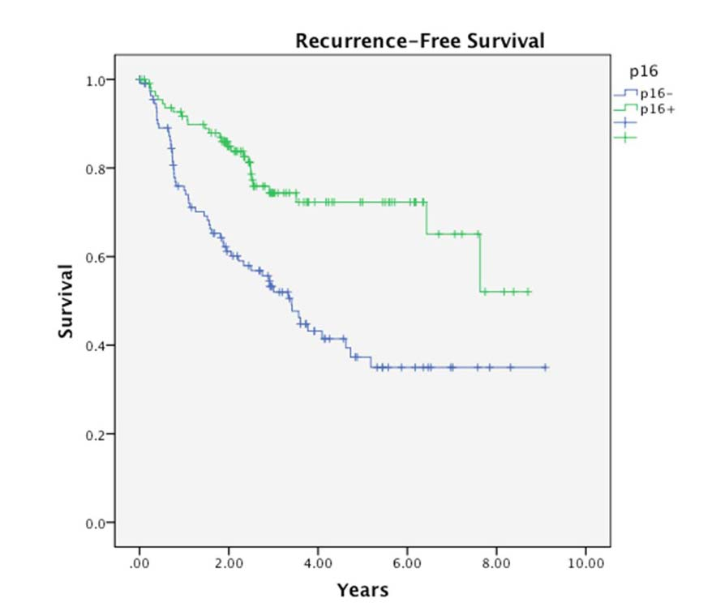

Simple example comparing two Kaplan-Meier curves

## Estimating the median and other percentiles

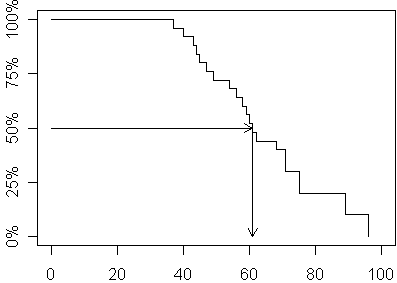

Schematic of survival curve starting from upper left corner

## Estimating a fixed time survival probability

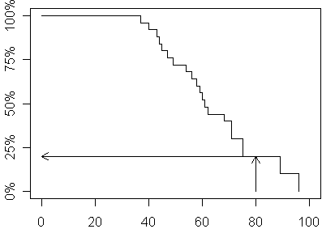

Schematic of survival curve starting from lower left corner

## Cox regression

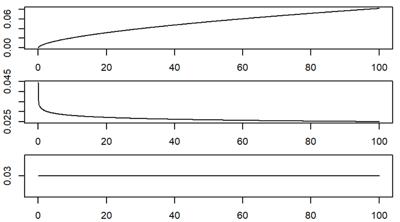

Illustration of increasing, decreasing, and constant hazards

## Alternatives to Cox regression

- Log rank test
  - Single categorical indpendent variable
  - Any number of levels
- Parametric survival models
  - Requires much stronger assumptions
  - Exponential, Weibull, or other distribution
  - Can extrapolare beyond the range of the data

## Cox regression - summary

- Time-to-event outcome
- Continuous or categorical independent variables
- Mutiple independent variables
  - Risk adjustment
  - Interactions
- Alternatives
  - Log rank test
  - Parametric models

## Summary - the big four models

- Linear regression
- Logistic regression
- Poisson regression
- Cox regression
- All very flexible
  - Allow categorical and continuous independent variables
  - Allow for risk adjustments and interactions

## Break #9

- What you have learned
  - Cox regression
- What’s coming next
  - Longitudinal/hierarchical designs

## Hierarchical/longitudinal designs

- Matching
- Baseline measures
- Longitudinal designs
- Cluster effects

## Matching

- Greatly improves precision
- Logistical issues
  - Close but not exact matches
  - Loss of data due to mismatches
  - Best when controls come from a large pool
- Analysis methods
  - Paired t-test
  - Random effects models

## Baseline measures

- Nice to have
  - Adjust for baseline imbalance
  - Improve precision
- Analysis methods
  - Change score
  - Baseline covariate
  - Bonate, Analysis of Pretest-Posttest Designs

## Longitudinal designs (1/2)

- Advantages
  - Rich, complete picture
  - Improved precision
- Disadvantages
  - Expensive
  - Dropout

## Longitudinal designs (2/2)

- Analysis methods
  - Within subject designs
  - Nested effects
  - Repeated measures
  - Split plot designs
  - Random effects models

## Cluster effects

- More than one source of variation
- Sources
  - Families
  - Clinics/Hospitals
  - Schools
  - Multicenter trials
- What is the unit of randomization?
- Analysis methods
  - Random effects models
  - Hierarchical models

## Break #10

- What you have learned
  - Longitudinal/hierarchical designs
- What’s coming next
  - Analysis of qualitative data

## Analysis of Qualitative Data-resources

- Typically, a one-hour interview requires a minimum of three to four hours (or more) of analysis.
- Involve the participants in the process, especially for narrative research.
- Tools:
  - focus groups
  - semi-structured interviews
  - participant observation
  - archival records

## Inductive process

- Start with the specific (raw data / transcript)
  - Develop a theoretical framework from the data
  - Conceptual categories emerge from the data
  - Iterative process
- Define the process
  - Who does the work
  - Privacy protections
  - How you will adapt

## Analysis process for qualitative data

- Your research question is only your starting point.
- Don’t let your question blind you to new information
- Build themes before you complete your data collection
  - Check back against the raw data
  - Look for negative examples
  - Don’t ignore infrequently voiced themes
- When have you achieved saturation?

## Coding the texts

- Balancing act
  - Level of creativity by coder to identify categories/relationships
  - Must reflect the informants thoughts
  - Audit of the coding by an independent person can check for the match between the coding and the source information
- Look for “negative cases”

## What goes in the methods section of a qualitative study

- Recruitment process
- Structure of the interview/focus group
- Recording and transcription details
- Software used to create categories
- Process to insure reliability
  - Multiple raters
  - Adjudication of disagreement
  - Other audits

## Summary

- Scales of measurement
- Quality check of data
- Data transformations
- Descriptive statistics
- Graphs
- Linear regression
- Logistic regression
- Poisson regression
- Cox regression
- Longitudinal/hierarchical designs
- Analysis of qualitative data